# STA 360/602: Assignment 4, Spring 2019

Kuei-Yueh Ko

Due at 10:00 AM on Monday, January 2019

# Problem 1: 3.10 Change of variables

## Part (a)

$$\theta \sim beta(a, b) \Rightarrow \frac{1}{\text{Beta}(a, b)} \theta^{a-1} (1-\theta)^{b-1}$$

$$\psi = g(\theta) = \log{\frac{\theta}{1 - \theta}} \Rightarrow \theta = h(\psi) = \frac{1}{1+e^{-\psi}}$$

$$p_\psi(\psi) = p_\theta(\theta) \times |\frac{dh}{d\psi}| = \frac{1}{\text{Beta}(a, b)} \Big(\frac{1}{1+e^{-\psi}}\Big)^{a-1} \Big(\frac{e^{-\psi}}{1+e^{-\psi}}\Big)^{b-1} \frac{e^{-\psi}}{(1+e^{-\psi})^2}$$

plot the $p_\psi(\psi)$ with parameter $a = 1, b = 1$

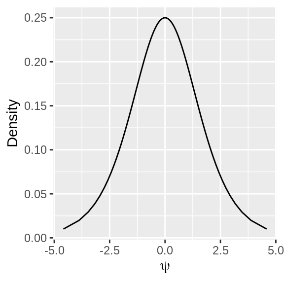

```r
### set up function
myfun <- function(psi, a, b){
    x = 1 / (1 + exp(-psi))
    #y = x^(a - 1) * (1 - x)^(b - 1) * exp(-psi)
    y = dbeta(x, shape1 = a, shape2 = b) * exp(-psi) * x^2
    return(y)
} # end func

### parameters
a = 1; b = 1
th  = seq(0, 1, length.out = 100)
th  = th[ -c(1, length(th)) ]
psi = log(th / (1-th))

### generate probability density
dat = data.frame(
    theta = th,
    psi   = psi,
    prob  = myfun(psi, a, b)
) # end df

### visualization
gp = ggplot(dat, aes(x = psi, y = prob)) +
    geom_line() +
    labs(x = expression(psi), y = "Density")
print(gp)
```

## Part (b)

$$\theta \sim gamma(a, b) \Rightarrow \frac{b^a}{\Gamma(a)} \theta^{a-1} e^{-b\theta}$$

$$\psi = g(\theta) = \log{\theta} \Rightarrow \theta = h(\psi) = e^{\psi}$$

$$p_\psi(\psi) = p_\theta(\theta) \times |\frac{dh}{d\psi}| = \frac{b^a}{\Gamma(a)} e^{\psi(a-1)} e^{-b e^{\psi}} \times e^{\psi} = \frac{b^a}{\Gamma(a)} \exp \{ a\psi - b e^{\psi} \}$$

plot the $p_\psi(\psi)$ with parameter $a = 1, b = 1$

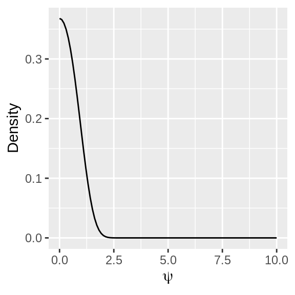

```r
### set up function
myfun <- function(psi, a, b){
    x = exp(psi)
    y = dgamma(x, shape = a, scale = b) * x
    return(y)
} # end func

### parameters
a = 1; b = 1
psi  = seq(0, 10, length.out = 100)

### generate probability density
dat = data.frame(
    psi   = psi,
    prob  = myfun(psi, a, b)
) # end df

### visualization
gp = ggplot(dat, aes(x = psi, y = prob)) +
    geom_line() +
    labs(x = expression(psi), y = "Density")
print(gp)
```

# Problem 2: Lab 04 Task 4 and Task 5

set up function to find the posterior

```r
findParam = function(prior, data){
    ### initialization
    c = prior$c
    m = prior$m
    a = prior$a
    b = prior$b
    n = length(data)

    ### calculate posterior and return the list of parameters
    postParam = data.frame(
        m = (c*m + n*mean(data))/(c + n),
        c = c + n,
        a = a + n/2,
        b = b +
            0.5 * (sum((data - mean(data))^2)) +
            (n*c *(mean(data)- m)^2)/(2*(c+n)))
  return(postParam)
}
```

set the data, prior and get the poster from data and prior

```r
### input data
x = c(18, 40, 15, 17, 20, 44, 38)
y = c(-4, 0, -19, 24, 19, 10, 5, 10,
      29, 13, -9, -8, 20, -1, 12, 21,
      -7, 14, 13, 20, 11, 16, 15, 27,
      23, 36, -33, 34, 13, 11, -19, 21,
      6, 25, 30,22, -28, 15, 26, -1, -2,
      43, 23, 22, 25, 16, 10, 29)
### store data in data frame
iqData = data.frame(
    Treatment = c(rep("Spurters", length(x)),
                  rep("Controls", length(y))),
    Gain = c(x, y))

### set prior and find posterior
prior = data.frame(m = 0, c = 1, a = 0.5, b = 50)
postS = findParam(prior, x)
postC = findParam(prior, y)
```

## Task 04

Simulate $\mu$ and $\lambda$ from the posterior. Then, count the incidents of $\mu_s > \mu_c$. The probability of $\mu_s > \mu_c$ can be approximated from the frequency of such incidents.

$$P(\mu_s > \mu_c | x_{1:n_s}, y_{1:n_c}) \approx \frac{1}{N} \sum_{i=1}^{N} \mathbb{1}(\mu_s^{(i)} > \mu_c^{(i)})$$

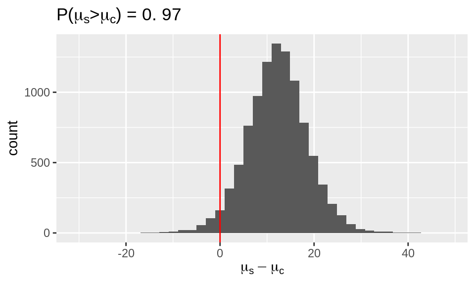

```r
### initialization
set.seed(123)
sim = 1e+4

### simulating lambda (1/sigma2) and mu (mean)
lambdas = rgamma(sim, shape = postS$a, rate = postS$b)
lambdac = rgamma(sim, shape = postC$a, rate = postC$b)
mus     = sapply(sqrt(1/(postS$c*lambdas)),rnorm, n = 1, mean = postS$m)
muc     = sapply(sqrt(1/(postC$c*lambdac)),rnorm, n = 1, mean = postC$m)

### arrange the results
simDF = data.frame(mu_diff = mus - muc)

### visualize
gp = ggplot(simDF, aes(x = mu_diff)) +
    geom_histogram(bins = 40) +
    geom_vline(xintercept = 0, color = "red") +
    labs(title = TeX(paste("P($\\mu_s > \\mu_c$) =", mean(simDF$mu_diff > 0))),
         x = TeX("$\\mu_s - \\mu_c$"))
print(gp)
```

## Task 05

**Does the parameters of prior conforms with our prior beliefs?**

From the simulate, we could observe

- the distribution of mu is symmetric around zero (blue line). That is, we do not know whether students will improve or not.
- the standard deviation of the changes is first set to be around 10 (red line).

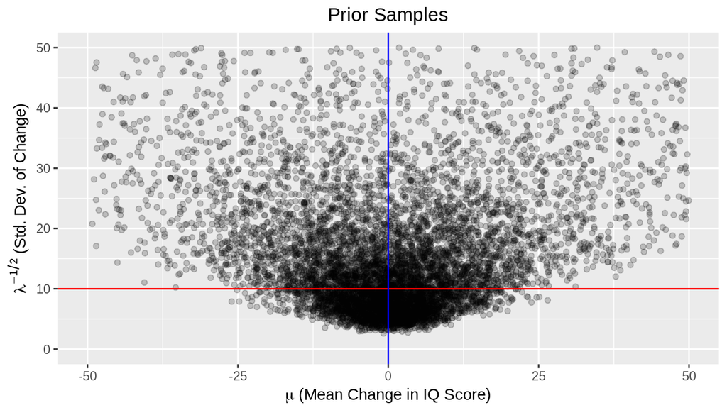

```r
### initialization
set.seed(123)
sim = 1e+4

### simulation
lambda = rgamma(sim, shape = prior$a, rate = prior$b)
mu = sapply(sqrt(1/(prior$c*lambda)),rnorm, n = 1, mean = prior$m)

### arrange the data
simDF = data.frame(lambda = lambda, mu = mu)
simDF$lambda = simDF$lambda^{-0.5}

## visualize the simulated paramters from the prior
gp = ggplot(data = simDF, aes(x = mu, y = lambda)) +
    geom_point(alpha = 0.2) + ylim(c(0, 50)) + xlim(c(-50, 50)) +
    geom_hline(yintercept = sqrt(prior$b/prior$a), color = "red") +
    geom_vline(xintercept = 0,                     color = "blue") +
    labs(title = "Prior Samples",
         x = expression(paste(mu, " (Mean Change in IQ Score)")),
         y = expression(paste(lambda^{-1/2}, " (Std. Dev. of Change)"))) +
    theme(plot.title = element_text(hjust = 0.5))
print(gp)
```

**Hypothetical datasets drawn using sampled parameters values simulated from prior**

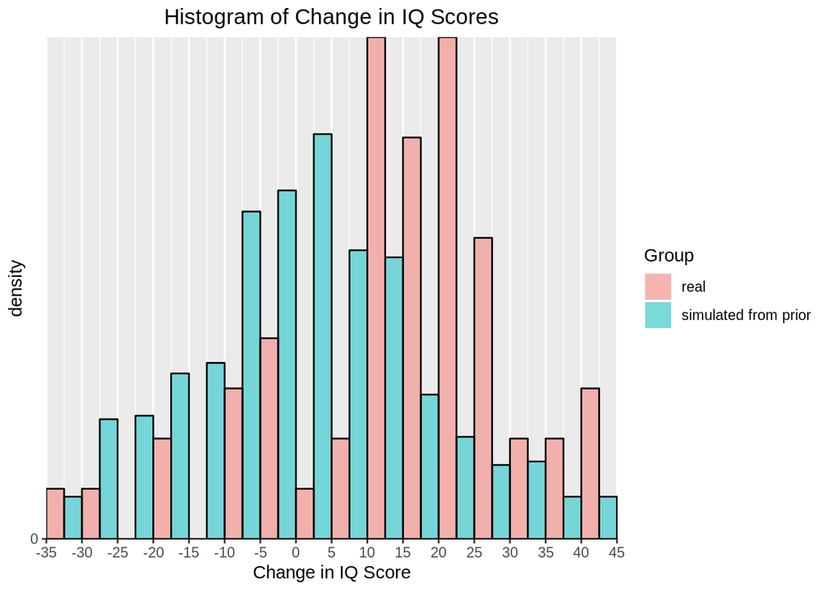

```r
### data
x = c(18, 40, 15, 17, 20, 44, 38)
y = c(-4, 0, -19, 24, 19, 10, 5, 10,
      29, 13, -9, -8, 20, -1, 12, 21,
      -7, 14, 13, 20, 11, 16, 15, 27,
      23, 36, -33, 34, 13, 11, -19, 21,
      6, 25, 30,22, -28, 15, 26, -1, -2,
      43, 23, 22, 25, 16, 10, 29)

### simualted parameters from prior
set.seed(123)
sim    = 1e+3 #length(x) + length(y)
lambda = rgamma(sim, shape = prior$a, rate = prior$b)
mu     = sapply(sqrt(1/(prior$c*lambda)),rnorm, n = 1, mean = prior$m)

### simualted data from prior
z = mapply(
    function(a_mu, a_sig){rnorm(1, mean = a_mu, sd = a_sig)},
    mu,
    1 / sqrt(lambda),
    SIMPLIFY = TRUE)

### store all data in data frame
iqData2 = data.frame(
    Treatment = c(rep("real",  length(x)),
                  rep("real",  length(y)),
                  rep("simulated from prior", length(z))),
    Gain = c(x, y, z))

### set up breaks of historgram with binwidth = 5
xLimits = seq(min(iqData$Gain) - (min(iqData$Gain) %% 5),
              max(iqData$Gain) + (max(iqData$Gain) %% 5),
              by = 5)

### visualization
gp = ggplot(data = iqData2, aes(
        x = Gain, y=..density..,
        fill = Treatment,
        colour = I("black"))) +
    geom_histogram(position = "dodge",
                   alpha = 0.5,
                   breaks = xLimits,
                   closed = "left") +
    scale_x_continuous(breaks = xLimits, expand = c(0,0))+
    scale_y_continuous(expand = c(0,0), breaks = seq(0, 10, by = 1))+
    labs(title = "Histogram of Change in IQ Scores",
         x = "Change in IQ Score", fill = "Group") +
    theme(plot.title = element_text(hjust = 0.5))
print(gp)
```